# Cyclistic bike-share analysis case study

# Data analysis method:

Ask ->Prepare -> Process -> Analyze -> Share -> Act

# Overview

In this blog is my process and perform to solve the problem of the case study: Cyclists bike-share. The main object of this case is “how to convert casual riders (customers who purchase full-day passes or single rides) to member riders (customers who purchase annual memberships). Particularly, the company wants to increase the number of their annual membership. You can find the full details of the case study here [link](https://divvy-tripdata.s3.amazonaws.com/index.html)

# Ask

As Junior Data Analyst, the questions that I need to anwser using the given dataset are:

- How do annual members and casual riders use Cyclistic bikes differently?
- Why would casual riders buy Cyclistic annual memberships?
- How can Cyclistic use digital media to influence casual riders to become members?

# Prepare

In this stage, I prepare the data by obtaining the data sets and storing it.The data sets was given as a monthly data in zip file. I downloaded the last 11 months of trip data which mean I downloaded 11 zip files. you can find the name of the files name was downloaded below:

- 202101-divvy-tripdata.zip
- 202102-divvy-tripdata.zip
- 202103-divvy-tripdata.zip
- 202104-divvy-tripdata.zip
- 202105-divvy-tripdata.zip
- 202106-divvy-tripdata.zip
- 202107-divvy-tripdata.zip
- 202108-divvy-tripdata.zip
- 202109-divvy-tripdata.zip
- 202110-divvy-tripdata.zip
- 202111-divvy-tripdata.zip

# Process

In this phase, I processed the data and prepared it for our next phase where we will uncover answers to our questions. I used DB Browser for SQLite for this step since the dataset is too large to merge and operate (around 5 million raws). “DB Browser for SQLite (DB4S) is a high quality, visual, open source tool to create, design, and edit database files compatible with SQLite.

At first, I imported all the 11 .csv files with DB Browser on my computer and I modified files name to the month short name. Then, I used Union function to combine the result of more SELECT statement, but it took too much time and crached after some point. I managed to merge the csv files without running any code in DB Browser for SQLite using into one large data-set and exported to my device.

Secondly, using Rstudio, I installed all necessary packages using install.packages()

Next, downloaded all the packages that are on essential part for my workflow for the analysis.

```r
library(ggplot2)
library(tidyr)
library(dplyr)
library(readr)
library(readxl)
```

The chunk code below is for importing the merged dataset

```r
bikeshare2021 <- read.csv("/Users/othmanalamoudi/Desktop/R-project/BikeShare_2021.csv")
```

let’s observe the number of rows & columns:

```r
nrow(bikeshare2021)
```

```
## [1] 5043983
```

```r
ncol(bikeshare2021)
```

```
## [1] 13
```

As you can see, our data set became very large with more than 5 millions row and 13 columns. Now let’s take a peek to the data set using head function, which shows only the fist rows - Side note: Iused knitr package to make the table looks pretty.

```r
library(knitr)
knitr::kable(head(bikeshare2021),"pipe")
```

| ride_id | rideable_type | started_at | ended_at | start_station_name | start_station_id | end_station_name | end_station_id | start_lat | start_lng | end_lat | end_lng | member_casual |
| --- | --- | --- | --- | --- | --- | --- | --- | --- | --- | --- | --- | --- |
| E19E6F1B8D4C42ED | electric_bike | 2021-01-23 16:14:19 | 2021-01-23 16:24:44 | California Ave & Cortez St | 17660 |  |  | 41.90034 | -87.69674 | 41.89 | -87.72 | member |
| DC88F20C2C55F27F | electric_bike | 2021-01-27 18:43:08 | 2021-01-27 18:47:12 | California Ave & Cortez St | 17660 |  |  | 41.90033 | -87.69671 | 41.90 | -87.69 | member |
| EC45C94683FE3F27 | electric_bike | 2021-01-21 22:35:54 | 2021-01-21 22:37:14 | California Ave & Cortez St | 17660 |  |  | 41.90031 | -87.69664 | 41.90 | -87.70 | member |
| 4FA453A75AE377DB | electric_bike | 2021-01-07 13:31:13 | 2021-01-07 13:42:55 | California Ave & Cortez St | 17660 |  |  | 41.90040 | -87.69666 | 41.92 | -87.69 | member |
| BE5E8EB4E7263A0B | electric_bike | 2021-01-23 02:24:02 | 2021-01-23 02:24:45 | California Ave & Cortez St | 17660 |  |  | 41.90033 | -87.69670 | 41.90 | -87.70 | casual |
| 5D8969F88C773979 | electric_bike | 2021-01-09 14:24:07 | 2021-01-09 15:17:54 | California Ave & Cortez St | 17660 |  |  | 41.90041 | -87.69676 | 41.94 | -87.71 | casual |

We have 13 columns and we can infer their content:

- **ride_id**: unique Id for each trip taken
- **rideable_type**: he type of a bike
- **started_at**: date and time of the start time
- **ended_at**: date and time of the end time
- **start_station_name**: name of the starting station
- **start_station_id**: id of the starting station
- **end_station_name**: Nnme of the ending station
- **end_station_id**: id of the ending station
- **start_lat**: latitude of the starting point
- **start_lng**: longitude of the starting point
- **end_lat**: latitude of the ending point
- **end_lng:** longitude of the ending point
- **member_casual**: the membership status (member, casual)

Looking at the column above, I figured I will be able to generate the distance travel where I will calculate the distance for each trip in **meter** using those four columns: start_lat, start_lng, end_lat and end_lng. For this I will need to use **Harversine* formula where I it will calculates the distance in meter. ( I had to google this to figure it out)

I started with creating two data frames:

- Point 1: start_lat , end_lng
- point 2: end_lat, start_lng

```r
point1 <- select(bikeshare2021, start_lat, end_lng)
point2 <- select(bikeshare2021, end_lat, start_lng)
```

Then I installed & loaded **geosphere** package so we can use **distHaversine()** Function

```r
library(geosphere)
```

Finally, I ran the chunk code below:

```r
bikeshare2021$distance_traveled <- distHaversine(point1,point2, r =6378137 )
```

Now we have 14 columns

Let’s take a peak at the distance_traveled column:

```r
df_distance_traveled <- select(bikeshare2021, start_lat, end_lng, end_lat, start_lng, distance_traveled)
knitr::kable(head(df_distance_traveled),"pipe")
```

| start_lat | end_lng | end_lat | start_lng | distance_traveled |
| --- | --- | --- | --- | --- |
| 41.90034 | -87.72 | 41.89 | -87.69674 | 2589.3665 |
| 41.90033 | -87.69 | 41.90 | -87.69671 | 746.6213 |
| 41.90031 | -87.70 | 41.90 | -87.69664 | 373.7393 |
| 41.90040 | -87.69 | 41.92 | -87.69666 | 746.8107 |
| 41.90033 | -87.70 | 41.90 | -87.69670 | 367.6726 |
| 41.90041 | -87.71 | 41.94 | -87.69676 | 1484.1007 |

Next, I wanted to find out the time each trip took. For this, I created new column named **date_diff** where using the **started_at** and **ended_at** columns where I can find the day difference. To do this, I used **as.date()** function

```r
bikeshare2021$date_diff <- as.Date(as.character(bikeshare2021$started_at), format = "%Y-%m-%d") - as.Date(as.character(bikeshare2021$ended_at), format = "%Y-%m-%d")
```

Here you can view the date_diff column

```r
df_date_diff <- select(bikeshare2021, started_at, ended_at, date_diff)
df_date_diff_asc <- arrange(df_date_diff, desc(-date_diff))
knitr::kable(head(df_date_diff_asc),"pipe")
```

| started_at | ended_at | date_diff |
| --- | --- | --- |
| 2021-06-04 22:03:33 | 2021-07-13 14:15:14 | -39 days |
| 2021-06-05 02:27:26 | 2021-07-13 22:51:35 | -38 days |
| 2021-05-02 02:56:07 | 2021-06-08 13:37:43 | -37 days |
| 2021-06-05 23:33:51 | 2021-07-12 13:55:14 | -37 days |
| 2021-07-08 19:29:49 | 2021-08-11 21:56:58 | -34 days |
| 2021-04-02 17:50:00 | 2021-05-05 22:06:42 | -33 days |

```r
filtered_bikeshare2021 <- bikeshare2021 %>% filter(date_diff >= 0)
```

Once filtered, I now have 5,003,104 rows which is 40,879 rows less than the beginning. Now once I have the day differences, I calculated time difference to find the duration in minutes for each trip using **difftime()** functions and specifying the unit with **mins**

```r
filtered_bikeshare2021$time_diff <- difftime(filtered_bikeshare2021$ended_at, filtered_bikeshare2021$started_at, units = "mins")
```

```r
df_time_diff <- select(filtered_bikeshare2021, started_at, ended_at, time_diff)
df_time_diff_asc <- arrange(df_time_diff, desc(-time_diff))
knitr::kable(head(df_time_diff_asc),"pipe")
```

| started_at | ended_at | time_diff |
| --- | --- | --- |
| 2021-11-07 01:54:36 | 2021-11-07 01:03:11 | -111.41667 mins |
| 2021-11-07 01:54:25 | 2021-11-07 01:03:44 | -110.68333 mins |
| 2021-11-07 01:54:12 | 2021-11-07 01:05:09 | -109.05000 mins |
| 2021-11-07 01:52:53 | 2021-11-07 01:05:22 | -107.51667 mins |
| 2021-11-07 01:51:21 | 2021-11-07 01:07:59 | -103.36667 mins |
| 2021-11-07 01:40:13 | 2021-11-07 01:00:29 | -99.73333 mins |

The time_diff in min can’t be a negative value because the time machine is not invented yet - remember? So again those are the observations we have to remove. To do this we will have to create a new data frame and use filter function again.

```r
filtered_bikeshare2021_v2 <- filtered_bikeshare2021 %>% filter(time_diff >= 0)
```

According to below code, around 100 rows were removed from the dataset.

```r
count(filtered_bikeshare2021) - count(filtered_bikeshare2021_v2)
```

```
##     n
## 1 105
```

Lastly, let’s create a column month which will display the number of the trip. To do this, I used the *format()* function

```r
filtered_bikeshare2021_v2$month <- format(as.Date(filtered_bikeshare2021_v2$started_at), "%m")
```

- ride_id
- start_station_id
- end_station_id
- start_lat
- start_lng
- end_lat
- end_lng
- date_diff

```r
bikeshare2021_cleaned_v1 <-
  select(filtered_bikeshare2021_v2, rideable_type,started_at,ended_at,start_station_name,end_station_name,member_casual,distance_traveled,time_diff,dayof_week,month)
```

Last step is to remove rows with missing values.

```r
bikeshare2021_cleaned_v2 <- bikeshare2021_cleaned_v1[complete.cases(bikeshare2021_cleaned_v1), ]
```

```r
write_csv(bikeshare2021_cleaned_v2,"/Users/othmanalamoudi/Desktop/R-project//final clean dataset.csv")
```

Final csv file size was around 690 MB, still big, but better that previous one.

# Analyze

## Descriptive analysis on time_diff ( all figures in minutes)

```r
mean (bikeshare2021_cleaned_v2$time_diff) # straight average (total ride length / rides)
```

```
## Time difference of 19.24025 mins
```

```r
median(bikeshare2021_cleaned_v2$time_diff) # midpoint number in the ascending array of ride lengths
```

```
## Time difference of 12.38333 mins
```

```r
max(bikeshare2021_cleaned_v2$time_diff) # longest ride
```

```
## Time difference of 1424.7 mins
```

```r
min(bikeshare2021_cleaned_v2$time_diff) #shortest ride
```

```
## Time difference of 0 mins
```

## Compare members and casual users [done]

```r
aggregate(bikeshare2021_cleaned_v2$time_diff ~ bikeshare2021_cleaned_v2$member_casual, FUN = mean)
```

```
##   bikeshare2021_cleaned_v2$member_casual bikeshare2021_cleaned_v2$time_diff
## 1                                 casual                      25.84303 mins
## 2                                 member                      13.45690 mins
```

```r
aggregate(bikeshare2021_cleaned_v2$time_diff ~ bikeshare2021_cleaned_v2$member_casual, FUN = max)
```

```
##   bikeshare2021_cleaned_v2$member_casual bikeshare2021_cleaned_v2$time_diff
## 1                                 casual                        1424.7 mins
## 2                                 member                        1248.9 mins
```

```r
aggregate(bikeshare2021_cleaned_v2$time_diff ~ bikeshare2021_cleaned_v2$member_casual, FUN = min)
```

```
##   bikeshare2021_cleaned_v2$member_casual bikeshare2021_cleaned_v2$time_diff
## 1                                 casual                             0 mins
## 2                                 member                             0 mins
```

## Visual the average ride time by each month for members vs caual riders [done]

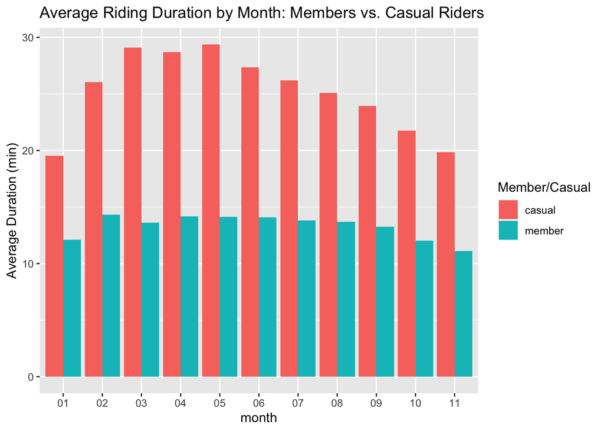

```r
bikeshare2021_cleaned_v2 %>% group_by(month,member_casual) %>%
  summarise(average_of_ride_time = mean(time_diff), .groups = 'drop') %>%
  ggplot(aes(x = month, y = average_of_ride_time, fill = member_casual)) +
  geom_col(position = 'dodge') +labs(x = "month", y = "Average Duration (min)", fill = "Member/Casual", title = "Average Riding Duration by Month: Members vs. Casual Riders")
```

## Visual the average ride time by each day for memebrs vs cauals riders [done]

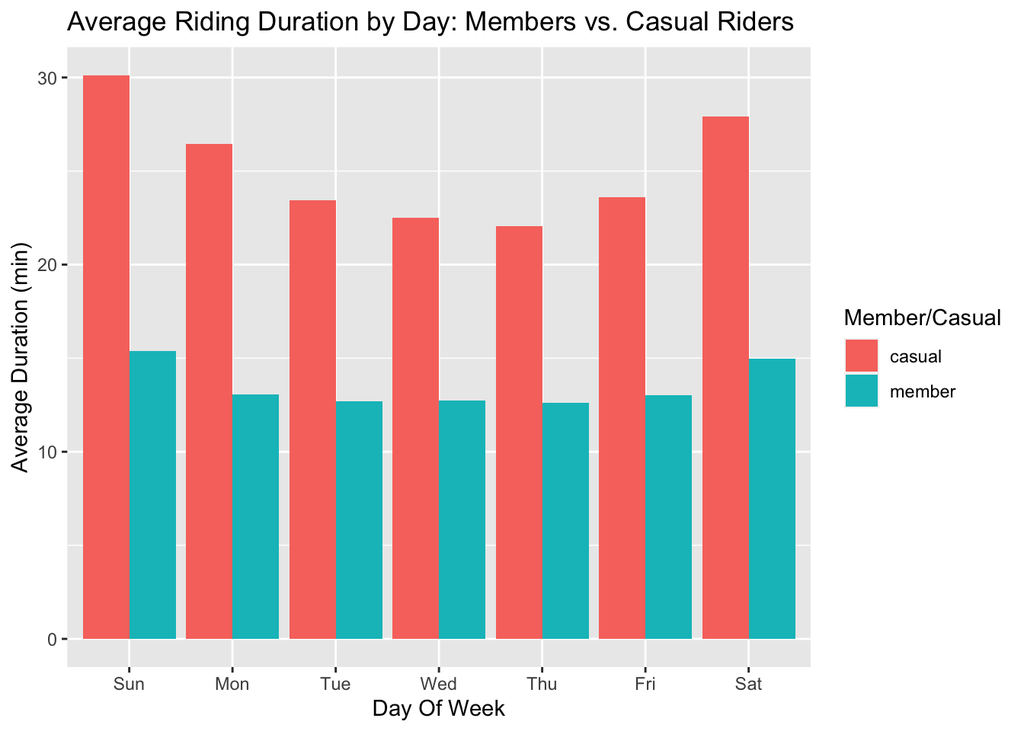

```r
bikeshare2021_cleaned_v2 %>% group_by(dayof_week,member_casual) %>%
  summarise(average_of_ride_time = mean(time_diff), .groups = 'drop') %>%
  ggplot(aes(x = dayof_week, y = average_of_ride_time, fill = member_casual)) +
  geom_col(position = 'dodge') + labs(x = "Day Of Week", y = "Average Duration (min)", fill = "Member/Casual", title = "Average Riding Duration by Day: Members vs. Casual Riders")
```

## visual the Average number of rides by month: member vs. Casual riders

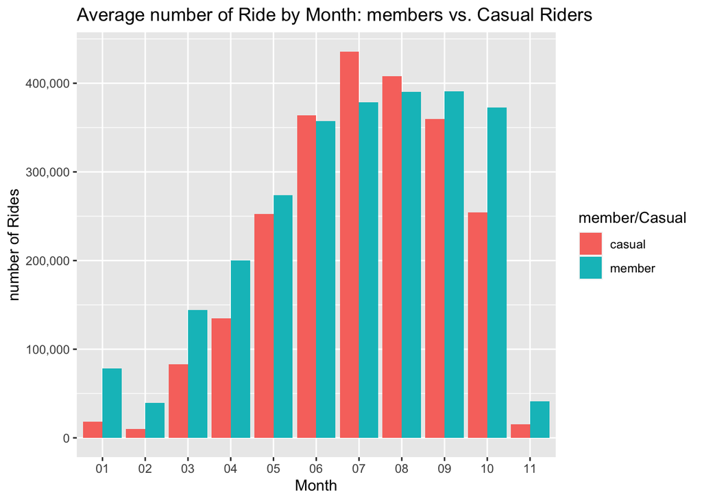

```r
bikeshare2021_cleaned_v2 %>%
  group_by(month, member_casual) %>%
  summarise(number_of_rides = n(), .groups = 'drop') %>%
  ggplot(aes(x= month, y = number_of_rides, fill = member_casual)) + geom_col(position = 'dodge') + scale_y_continuous(labels = scales::comma) + labs(x = "Month", y = "number of Rides", fill = "member/Casual", title = "Average number of Ride by Month: members vs. Casual Riders")
```

## Visual the Average Number of Rides by Day: Members vs. Casual Riders[done]

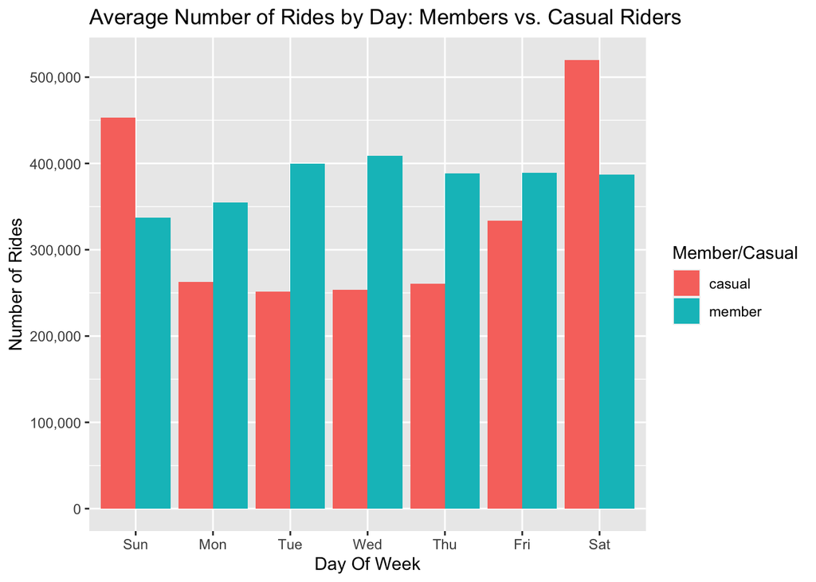

```r
bikeshare2021_cleaned_v2 %>% group_by(dayof_week,member_casual) %>%
  summarise(number_of_ride = n(), .groups = 'drop') %>%
  ggplot(aes(x = dayof_week, y = number_of_ride, fill = member_casual)) +
  geom_col(position = 'dodge')+scale_y_continuous(labels = scales::comma) +labs(x = "Day Of Week", y = "Number of Rides", fill = "Member/Casual", title = "Average Number of Rides by Day: Members vs. Casual Riders")
```

## Visual for number of rides grouped by day: rider type [done]

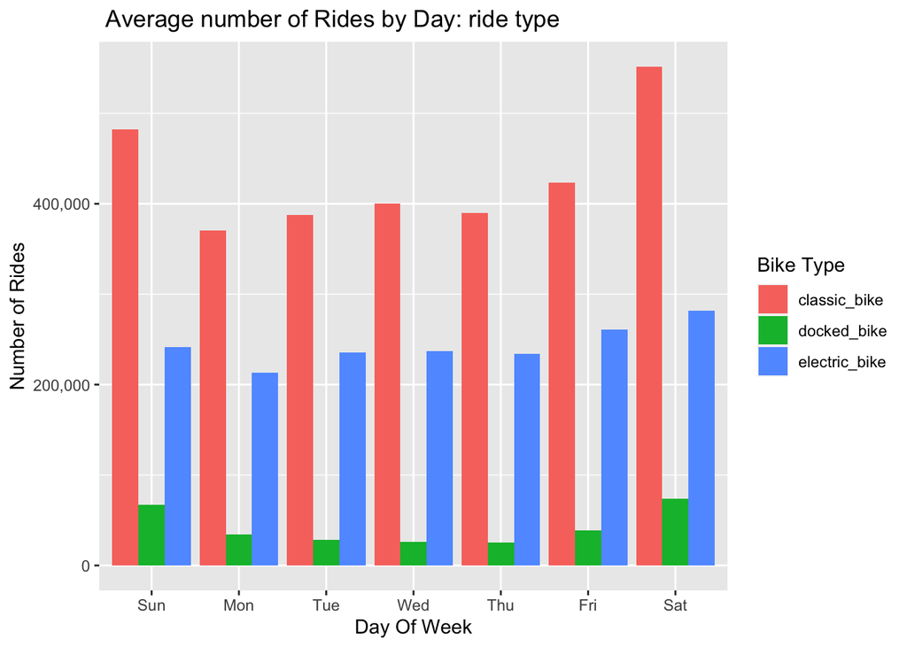

```r
bikeshare2021_cleaned_v2 %>% group_by(dayof_week ,rideable_type) %>%
  summarise(number_of_ride = n(), .groups = 'drop') %>%
  ggplot(aes(x = dayof_week, y = number_of_ride, fill = rideable_type)) +
  geom_col(position = 'dodge') + scale_y_continuous(labels = scales::comma) + labs(x= "Day Of Week", y = "Number of Rides", fill = "Bike Type", title = " Average number of Rides by Day: ride type" )
```

## Visualfor Top 10 Used Start Stations [done]

```r
#replacing empty rows with NA
bikeshare2021_cleaned_v2[bikeshare2021_cleaned_v2 == ""] <- NA

#removing NA value
bikeshare2021_cleaned_v3 <- na.omit(bikeshare2021_cleaned_v2)
#get the top 10 popular start station for member and causal
top_10_start_staction_name <- bikeshare2021_cleaned_v3 %>% group_by(start_station_name) %>% summarise(station_count = n()) %>% arrange(desc(station_count)) %>% head(n = 10)
```

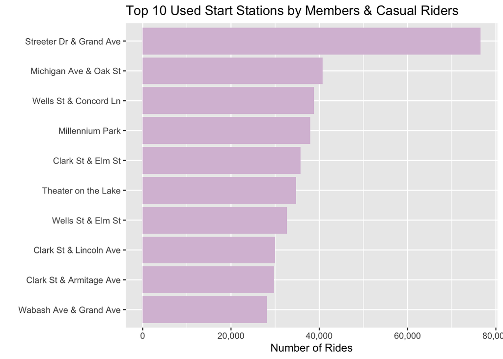

```r
ggplot(data = top_10_start_staction_name)+ geom_col(aes(x = reorder(start_station_name, station_count), y = station_count), fill= "thistle") + coord_flip() + labs(title = "Top 10 Used Start Stations by Members & Casual Riders", y = "Number of Rides", x = "") + scale_y_continuous(labels = scales::comma)
```

[output not shown]